# Intro til Statistik i R

Johanne Brandhøj Würtz, AUL BSS

2024-09-03

Velkommen til workshoppen i R! Formålet med denne workshop er at give en introduktion til programmeringssproget R, der egner sig rigtig godt til statistik. Vi kommer til at gennemgå nogle generelt anvendelige funktioner, der relaterer sig til deskriptiv statistik i R. Vores data stammer fra bogen ‘Introduktion til R’ at Erik Gahmer Larsen fra 2024 (Hans Reitzels Forlag) og omhandler valgresultater fra folketingsvalg

# Layout

Brugergrænsefladen består af fire vinduer. Hvert vindue bidrager med forskellige former for funktioner og overblik. Første vindue (øverst til venstre) er den primære grænseflade. Det er her vi skriver vores kode. Andet vindue (nederst til venstre) indeholder blandt andet vores konsol. Det er her vores kode bliver eksekveret og kan altså ses som værende det bagvedlingende lag - selve ‘computeren/lommeregneren’. Tredje vinue (øverst til høje) viser blandt andet det enviroment vi arbejder i, når vi har lavet et projekt. Et enviroment skal her forstås som en oversigt over de variable vi bruger i vores kode (objekter). Vi bruger blandt andet en variable når vi indlæser vores data og gemmer det under et sigende navn. En variable indeholder altså værdier som bliver tildelt af os. Fjerde vindue (nederst til højre) viser blandt andet det mappe- og filsystem vi befinder os i. På den måde kan man let se, hvordan ens filer er organiseret i ens projekt. Dette er relevant når vi skal indlæse vores data, da R skal vide præcist, hvor den skal finde de bestemte filer for at kunne anvende dem.

Dette script er i R Markdown format, hvilket vil sige, at det både kan indeholde forklarende tekst (som dette i læser her) og noter samt kode i programmeringssproget R. De grå bokse markeret med ´´´ er vores kodeblokke. Det er her vi skriver og kører vores kode. En kodeblok køres når man trykker på den lille grønne pil i blokkens højre hjørne. Kode kan også køres ved at taste ctrl + enter når ens mus er ud fra den gældende linje i den grå boks.

# Forberedelse

Det første vi gør, er at installere de pakker vi skal bruge. Disse pakker udvider basesfunktionaliteten, og gør det blandt andet muligt atlave mere avanceret statistik samt informationsrige visualiseringer.

```r
#install.packages("readxl")
#install.packages("tidyverse")
#install.packages("ggplot2")
```

Pakkerne er nu installeret i dit lokale R og vi skal nu loade pakkerne for at aktivere dem i netop denne session.

```r
library(readxl)
library(tidyverse)
```

```r
library(ggplot2)
```

# Data

Vi skal nu til at indlæse og gemme vores data omhandlende valgresultater i en variabel. Vi kalder vores variabel noget beskrivende og genkendeligt, der beskriver indholdet.

Vores data stammer som sagt fra Erik Gahner Larsens bog ‘Introduktion til R’ (2022) og indeholder forskellige informationer omhandlende folketingsvalg i Danmark. Det data vi skal arbejde med findes i undermappen ‘data’. Her ligger vores data i en excel fil fordelt på to ark/sheets. Det første af de to ark indeholder en tabel over antal stemmer fordelt på parti, og det næste ark indeholder en tabel over antal mandater fordelt på parti.

Måden hvorpå man indlæser sit data afhænger af, hvordan dataen er gemt. Vi skal arbejde med data fra excel og derfor skal vi indlæse dataen på en særlig måde med en særlig funktion (read_excel). Havde vi derimod en csv fil eller et andet format, ville vi skulle bruge en anden funktion til at indlæse vores data i R (eks. read_csv). Forskellige dataformater kræver forskellige pakker, men det er muligt at indlæse langt de fleste dataformater ind i R. Det er helt okay ikke at kunne huske disse funktioner og det er nemt at slå op, hvis man kommer i tvivl.

```r
fv_votes <- read_excel("data/folketingsvalg.xlsx", sheet = "votes")
fv_seats <- read_excel("data/folketingsvalg.xlsx", sheet = "seats")
```

Man kan nu se, at variablerne er i vores enviroment (vinduet øverst til højre). Ved at trykke på navnet, kan vi se vores data i en tabel. Vi kan også få overblik og inblik i vores data ved at bruge en række funktioner i R.

```r
#Viser de første linjer af vores datasæt
head(fv_votes)
```

| year | votes_s | votes_rv | votes_k | votes_cd | votes_rfb | votes_sf | votes_dkp | votes_df | votes_fk | votes_lc | votes_kd | votes_sp | votes_u | votes_v | votes_vs | votes_fp | votes_el | votes_la | votes_alt | votes_nb | votes_krp | votes_sk | votes_total |
| --- | --- | --- | --- | --- | --- | --- | --- | --- | --- | --- | --- | --- | --- | --- | --- | --- | --- | --- | --- | --- | --- | --- | --- |
| 1953 | 894913 | 169295 | 364960 | NA | 75449 | NA | 93824 | NA | NA | NA | NA | 9721 | 58573 | 499656 | NA | NA | NA | NA | NA | NA | NA | NA | 2172036 |
| 1957 | 910170 | 179822 | 383843 | NA | 122759 | NA | 72315 | NA | NA | NA | NA | 9202 | 53061 | 578932 | NA | NA | NA | NA | NA | NA | NA | NA | 2321097 |
| 1960 | 1023794 | 140979 | 435764 | NA | 52330 | 149440 | 27298 | NA | NA | NA | NA | 9058 | 81134 | 512041 | NA | NA | NA | NA | NA | NA | NA | NA | 2439936 |
| 1964 | 1103667 | 139702 | 527798 | NA | 34258 | 151697 | 32390 | NA | NA | NA | NA | 9274 | 65756 | 547770 | NA | NA | NA | NA | NA | NA | NA | NA | 2640856 |
| 1966 | 1068911 | 203858 | 522028 | NA | 19905 | 304437 | 21553 | NA | NA | 69180 | NA | NA | 44994 | 539027 | NA | NA | NA | NA | NA | NA | NA | NA | 2802304 |
| 1968 | 974833 | 427304 | 581051 | NA | 21124 | 174553 | 29706 | NA | NA | 37407 | NA | 6831 | 14360 | 530167 | 57184 | NA | NA | NA | NA | NA | NA | NA | 2864805 |

```r
#viser de sidste linjer i vores datasæt
tail(fv_seats)
```

| year | seats_s | seats_rv | seats_k | seats_cd | seats_rfb | seats_sf | seats_dkp | seats_df | seats_fk | seats_lc | seats_kd | seats_sp | seats_u | seats_v | seats_vs | seats_fp | seats_el | seats_la | seats_alt | seats_nb | seats_krp | seats_sk |
| --- | --- | --- | --- | --- | --- | --- | --- | --- | --- | --- | --- | --- | --- | --- | --- | --- | --- | --- | --- | --- | --- | --- |
| 2001 | 52 | 9 | 16 | 0 | NA | 12 | NA | 22 | NA | NA | 4 | NA | NA | 56 | NA | 0 | 4 | NA | NA | NA | NA | NA |
| 2005 | 47 | 17 | 18 | 0 | NA | 11 | NA | 24 | NA | NA | 0 | NA | NA | 52 | NA | NA | 6 | NA | NA | NA | NA | NA |
| 2007 | 45 | 9 | 18 | NA | NA | 23 | NA | 25 | NA | NA | 0 | NA | NA | 46 | NA | NA | 4 | 5 | NA | NA | NA | NA |
| 2011 | 44 | 17 | 8 | NA | NA | 16 | NA | 22 | NA | NA | 0 | NA | NA | 47 | NA | NA | 12 | 9 | NA | NA | NA | NA |
| 2015 | 47 | 8 | 6 | NA | NA | 7 | NA | 37 | NA | NA | 0 | NA | NA | 34 | NA | NA | 14 | 13 | 9 | NA | NA | NA |
| 2019 | 48 | 16 | 12 | NA | NA | 14 | NA | 16 | NA | NA | 0 | NA | NA | 43 | NA | NA | 13 | 4 | 5 | 4 | 0 | 0 |

- select(): gør det i dette tilfælde muligt at udvælge specifikke kolonner fra vores primære datasæt og overføre dem til et nyt og mindre datasæt.
- pivot_longer(): en af tidypakkens meget brugte funktioner. Her komprimerer vi datasættet ved at gå fra ni kolonner til tre. Dette gør vi for at få et mere meningsfyldt datasæt, hvor parti og antal stemmer får hver sin kolonne
- max(): Finder max værdien
- min(): Finder min værdien
- summary(): Viser oversigt over deskriptive informationer
- filter(): Gør det muligt at udvælge data fra eks. et specifikt år
- ggplot(): anvendes (i dette tilfælde) til at lave et ‘avanceret’ søjlediagram

```r
#Udvælg centrale partier - her er det de partier, der blev valgt ind i folketinget i 2019
fv_2019 <- select(fv_votes, "year", "votes_s", "votes_df", "votes_v", "votes_el", "votes_la", "votes_alt", "votes_rv", "votes_sf")

#Komprimer tabellen for folketinget i 2019, så partierne samles i en kolonne og antal stemmer samles i en anden kolonne
fv_2019 <- pivot_longer(fv_2019, cols = 2:9, names_to = "parti", values_to = "stemmer")

#Finder max værdien i kolonnen
max(fv_2019$stemmer, na.rm = TRUE)
```

```
## [1] 1223620
```

```r
#Finder min værdien i kolonnen
min(fv_2019$stemmer, na.rm = TRUE)
```

```
## [1] 54038
```

```r
#Viser oversigt over min, max, median, mean etc.
summary(fv_2019$stemmer)
```

```
##    Min. 1st Qu.  Median    Mean 3rd Qu.    Max.    NA's
##   54038  179622  353832  473200  791832 1223620      76
```

# Visualisering

Vi skal nu til anvende vores data til at lave en række visualiseringer. Til dette bruger vi pakken ggplot.

I nedenstående visualisering definerer vi følgende parametre: - Fitrerer at vi kun er interesserede i år 2019 - Vi laver en visualisering i ggplot - X aksen består af parti rangeret efter, at flest stemmer er øverst og mindst stemmer er nederst - y aksen består af antal stemmer - fill/fyldfarven skal relatere sig til antallet af stemmer - Visualiseringen skal være et søjlediagram - Vi bytter om på placeringen af x og y aksen, da det så er nemmere at aflæse visualiseringen - Vi giver labels/navne til x og y aksen - Vi anvender en farveskala fra ggplot, der gør det nemmere at aflæse visualiseringen

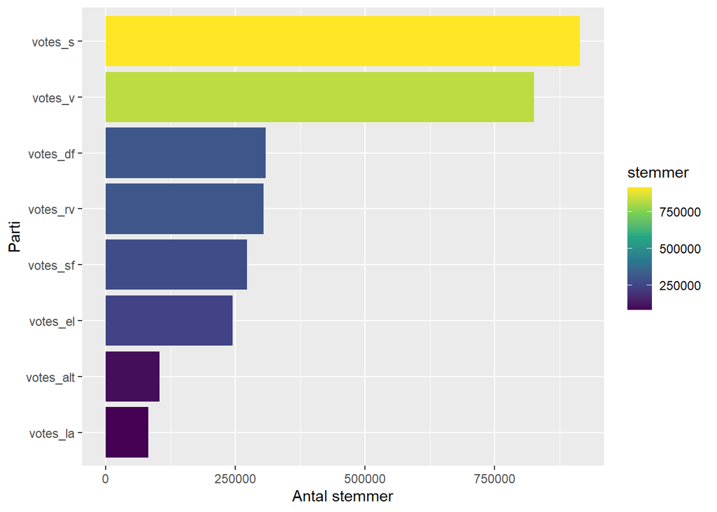

```r
#Visualisering af antallet af stemmer pr. parti ved folketingsvalget i 2019 for de partier, der blev valgt ind
fv_2019 %>%
  filter(year == 2019) %>%
  ggplot(aes(x = reorder(parti, stemmer), y = stemmer, fill = stemmer))+
  geom_col()+
  coord_flip()+
  labs(x = "Parti", y = "Antal stemmer")+
  scale_fill_viridis_c()
```

Til næste visualisering genbruger vi de fleste af funktionerne fra tidligere. Den eneste nye tilføjelse er funtionen factor(). Denne gør det muligt at inddele i ‘kategorier’/‘niveauer’. Hvilket vi er interesseret i, da det giver en mere forklarende visualisering af årstal i vores tilfælde.

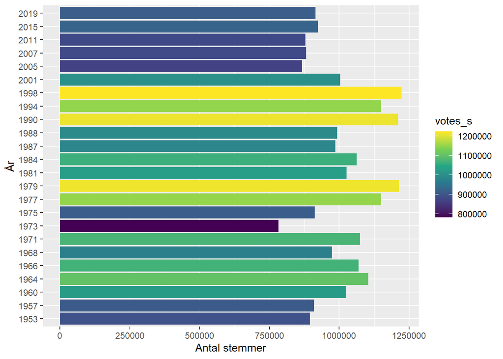

```r
#Udvælg de kolonner/variable som vi ønsker i tabellen. Her der det socialdemokratiet og årstal vi er interesserede i
fv_votes_s <- fv_votes %>%
  select(votes_s, year)

#Visualisering af antallet af stemmer for Socialdemokratiet fra 1953 til 2019
fv_votes_s %>%
  ggplot(aes(x = factor(year), y = votes_s, fill = votes_s))+
  geom_col()+
  coord_flip()+
  labs(x = "År", y = "Antal stemmer")+
  scale_fill_viridis_c()
```

# Kombination af to datasæt

Det sidste vi gennemgår er, hvordan man sammenfletter to datasæt, så det bliver et samlet datasæt. Dette gør det muligt at lave nogle analyser og visualiseringer, der ikke er mulige, hvis ens data lægger spredt i forskellige datasæt.

Vi ønsker at sammelægge de to datasæt vi indlæste i starten af scriptet; Henholdsvis fv_votes og fv_seats. Når man skal sammenlægge to datasæt, skal R have at vide, hvordan det skal sammelægge dem. Dvs. hvilket datasæt, der skal føjes til et eksisterende, samt hvilken variabel R skal tage udgangspunkt i. For at få et meningsfuldt datasæt ud af sammenlægningen, er det vigtigt at gøre sig overvejelser om, hvordan de to datasæt ser ud. Har de nogle variabler der går igen, hvor det ville være meningsfuldt at sammenflette, og er de udformet på nogenlunde samme facon. Dette kan godt virke lidt forvirrende, men det kommer forhåbenligt til at give mening med eksemplet nedenfor.

Hvis vi starter med at kigge på de to datasæt vi ønsker sammenlagt, kan vi se, at de ikke helt har samme form. fv_votes har 24 observationer, dvs. rækker og 24 variabler dvs. kolonner. Kigger vi derimod på fv_seats, har dette datasæt 24 observationer, men kun 23 rækker. Helt lavpraktisk skyldes dette, at votes_total er at finde i fv_votes. Denne er essentiel, da antallet af stemmer varierer fra år til år. Der findes derimod ikke en seats_total i fv_seats, da antallet af mandater er fast uafhængig af år (175). Vi har altså to datasæt, der som udgangspunkt ligner hinanden rigtig meget, men hvor der er lidt forskel i størrelsen. Det er til vores fordel, at de to datasæt deler en variabel, nemlig ‘year’. Det gør det muligt for os, at sammenflette de to datasæt med udgangspunkt i denne unikke variable, så vi sikre os, at dataen bliver overført til de rigtige rækker under de rigtige kolonner. Variablen er unik, da hvert årstal kun optræder en gang i hver af de to datasæt. Vi kan derfor se det som et ID eller et CPR. nummer, der er unik for hver række. Vi bruger derfor variablen ‘year’ som en form for nøgle, når vi skal sammenflette de to datasæt.

```r
#Sammenflet de to datasæt med udgangspunkt i den fælles variable 'years'
fv <- left_join(fv_votes, fv_seats, by = "year")

#Lav et nyt datasæt, hvor relevante variable optræder - obs. vi er interesserede i kolonnen votes_total, da andel udregnes med afsæt i det fulde antal
fv_v <- fv %>%
  select(year, votes_v, seats_v, votes_total) %>%
  mutate(andel_stemmer = votes_v / votes_total) %>%
  mutate(andel_mandater = seats_v / 175)

#Se en oversigt over fordelingen af andel stemmer og mandater for Venstre
summary(fv_v)
```

```
##       year         votes_v           seats_v       votes_total
##  Min.   :1953   Min.   : 353280   Min.   :19.00   Min.   :2172036
##  1st Qu.:1970   1st Qu.: 403424   1st Qu.:22.00   1st Qu.:2894273
##  Median :1982   Median : 534597   Median :36.50   Median :3229882
##  Mean   :1984   Mean   : 606023   Mean   :35.12   Mean   :3124629
##  3rd Qu.:1999   3rd Qu.: 785856   3rd Qu.:42.25   3rd Qu.:3399882
##  Max.   :2019   Max.   :1077858   Max.   :56.00   Max.   :3579675
##  andel_stemmer    andel_mandater
##  Min.   :0.1045   Min.   :0.1086
##  1st Qu.:0.1236   1st Qu.:0.1257
##  Median :0.1999   Median :0.2086
##  Mean   :0.1939   Mean   :0.2007
##  3rd Qu.:0.2337   3rd Qu.:0.2414
##  Max.   :0.3093   Max.   :0.3200
```

```r
#Filtrer efter det år, hvor Venstre havde den mindste andel af stemmerne
fv_v %>%
  filter(andel_stemmer == min(andel_stemmer))
```

| year | votes_v | seats_v | votes_total | andel_stemmer | andel_mandater |
| --- | --- | --- | --- | --- | --- |
| 1987 | 354291 | 19 | 3389201 | 0.1045353 | 0.1085714 |

```r
#Filtrer efter det år, hvor Venstre havde den største andel af stemmerne
fv_v %>%
  filter(andel_stemmer == max(andel_stemmer))
```

| year | votes_v | seats_v | votes_total | andel_stemmer | andel_mandater |
| --- | --- | --- | --- | --- | --- |
| 2001 | 1077858 | 56 | 3484915 | 0.3092925 | 0.32 |